# ch.9 Reference and Physical Maps

Jung Eun Park

Thursday, January 01, 2015

ch.9 Reference and Physical Maps

9.1.1 Retrieving Data

```r
library(raster)
library(rasterVis)
```

```r
library(maptools)
library(rgeos)
library(latticeExtra)
library(colorspace)
#gpclibPermit()

#longitude-latitude projection
proj <- CRS(' +proj=longlat +ellps=WGS84')

#working directory를 각자 저장한 폴더경로로 재설정할것!
old <- setwd("C:/downloads/1409_DataVisualization/14DV_part3/03_150109")

brazilAdm <- readShapePoly('BRA_adm1.shp',proj4string=proj)
Encoding(levels(brazilAdm$NAME_1)) <- 'latin1'

# DEM
brazilDEM <- raster('BRA_alt')
worldRiv <- readShapeLines('ne_10m_rivers_lake_centerlines', proj4string=proj)

#sea depth
worldSea <- raster('OB_LR/OB_LR.tif')
```

[output not shown]

```r
brazilSea <- crop(worldSea, brazilDEM)
setwd(old)
```

9.1.2 Intersection of Shapefiles and Elevation Model

- Natural Earth Data에서 받은 river/lake 자료는 전세계 기준이라서 브라질 부분만 가져오기 -> rgeos 패키지의 gIntersection 함수 사용
- 이 공간데이터들은 sp패키지 클래스로 변환되어야 하므로, brazilDEM 의 경계들을 Spatial-Polygon으로 변환해야 함
- 새로 가져온 intersection 은 새 spatialline오브젝트(brazilRiv)

```r
# Only those features labeled as "River" are needed
worldRiv<- worldRiv[worldRiv$featurecla=='River',]
# Define the extent of Brazil as an SpatialPolygons
extBrazil <- as(extent(brazilDEM), 'SpatialPolygons')
proj4string(extBrazil) <- proj

# and intersect it with worldRiv to extract brazilian rivers from the world database
brazilRiv <- gIntersection(worldRiv, extBrazil, byid=TRUE)
# and specially the famous Amazonas River
amazonas <- worldRiv[worldRiv$name=='Amazonas',]
```

9.1.3 Labels

```r
# coordinates 메서드: Brazil 내 각 지역의 이름을 각 polygon의 중심에 배치
centroids <- coordinates(brazilAdm)
# 상위의 국가이름 라벨을 각 지역 중심의 평균지점에 배치
xyBrazil <- apply(centroids, 2, mean)

# 이름이 two words 이상인 경우 split
admNames <- strsplit(as.character(brazilAdm$NAME_1), ' ' )

admNames <- sapply(admNames,
                 FUN=function(s){
                   sep=if (length(s)>2) '\n' else  ' '
                   paste(s, collapse=sep)
                   })
```

9.1.4 Overlaying Layers of Information

- 여기서 지형도는 다음의 4개의 레이어로 구성된다.
- 1. 바다수심(sea depth) raster : rasterVis 패키지의 levelplot

```r
#brewer.pal의 청색으로 시각화
blueTheme <- rasterTheme(region=brewer.pal(n=9, 'Blues'))

seaPlot <- levelplot(brazilSea, par.setting=blueTheme,
              maxpixels=1e6,
              panel=panel.levelplot.raster,
              margin=FALSE, colorkey=FALSE)
```

- 2. 표고(altitude) raster : colorspace 패키지의 terrain_hcl

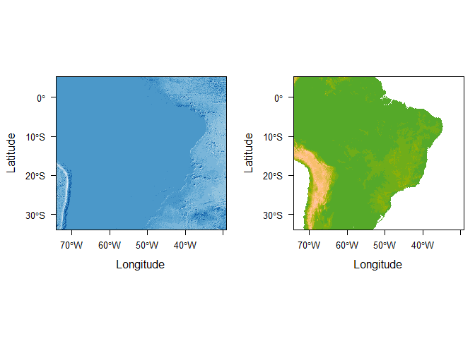

```r
#terrain colors
terrainTheme <- rasterTheme(region=terrain_hcl(15))

altPlot <- levelplot(brazilDEM, par.settings=terrainTheme,
                maxpixels=1e6,panel=panel.levelplot.raster,
                margin=FALSE, colorkey=FALSE)

print(seaPlot, split=c(1, 1, 2, 1), more=TRUE)
print(altPlot, split=c(2, 1, 2, 1))
```

```r
#dev.off()
```

- 3. rivers : SpatialLinesDataFrame Object

```r
amazonasLab <- label(amazonas,'Amazonas')
```

- 4. 행정경계(Administrative boundaries) : SpatialPolygonsDataFrame

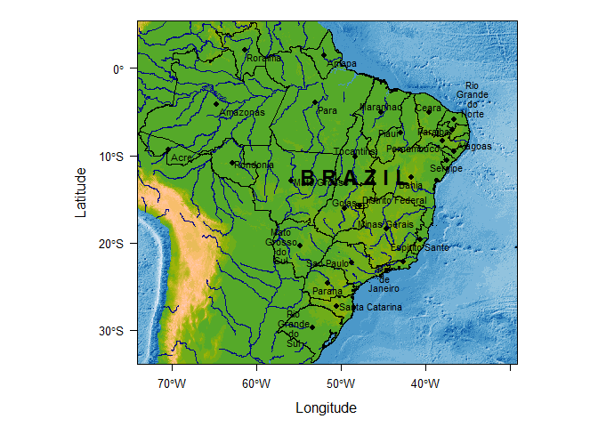

```r
seaPlot + altPlot + layer({
  # Rivers 강
  sp.lines(brazilRiv, col='darkblue', lwd=0.2)
  # 아마존 강 Amazonas - thicker line
  sp.lineLabel(amazonas, amazonasLab,
               lwd=1, col='darkblue', col.line='darkblue',
               cex=0.5, fontfamily='Palatino')
  # Administrative boundaries 행정경계
  sp.polygons(brazilAdm, col='black', lwd=0.2)
  # centroids of Administrative boundaries 행정지역중심
  panel.points(centroids, col='black')
  # with their labels 행정지역명
  panel.pointLabel(centroids, labels=admNames,
                   cex=0.7, fontfamily='Palatino', lineheight=0.8)
  # Country Name 국가명
  panel.text(xyBrazil[1], xyBrazil[2], labels='B R A Z I L',
             cex=1.5, fontfamily = 'Palatino', fontface=2)
})
```

```r
#dev.off()
```

9.2 OpenStreetMap with Hill Shade Layers

- 스페인 북부 Madrid Galacia의 Cedeira와 Valdovino의 바다, 해변, 숲을 지도에 시각화
- 다음의 3단계로 구성
- step.1 OpenStreetMap project로부터 정보 취득
- step.2 지형을 시각화하기 위한 레이어생성
- step.3 각 레이어를 순서에 맞게 시각화

9.2.1 Retrieving Data from OpenStreetMap

- step.1 OpenStreetMap project로부터 정보 취득
- osmar 패키지: OpenStreetMap 서비스에서 raw data 추출
- R코드 :

library(osmar) api <- osmsource_api()

# get_osm function retrives a region defined by corner_bbox using OSM API

ymax <- 43.7031 ymin <- 43.6181 xmax <- -8.0224 xmin <- -8.0808 box <- corner_bbox(xmin, ymin, xmax, ymax) cedeira <- get_osm(box, source=api, full=TRUE)

- Cedeira 오브젝트는 3개의 주요부분으로 구성 : nodes, ways, relations
- find : 각 구성부분을 검색하여 인덱스화
- R 코드:

streets <- spFromOSM(cedeira, way(idxStreets)) primary <- spFromOSM(cedeira, way(idxPrimary)) secondary <- spFromOSM(cedeira, way(idxSecondary)) tertiary <- spFromOSM(cedeira, way(idxTertiary)) other <- spFromOSM(cedeira, way(idxOther))

# place 이름별로 SpatialPoints 오브젝트화

idxPlaces <- find(cedeira, node(tags(k==‘name’))) places <- spFromOSM(cedeira, node(idxPlaces), ‘points’)

nms <- subset(cedeira$nodes$tags, subset=(k==‘name’), select=c(‘id’, ‘v’)) ord <- match(idxPlaces, nms$id) nms <- nms[ord,] places$name <- nms$v[ord]

# Cedeira town will be printed differently

idxCedeira <- which(nms$v==‘Cedeira’) #Main town cedeiraCoords <- coordinates(places[idxCedeira,]) places <- places[-idxCedeira,]

9.2.2 Hill Shading

- step.2 지형을 시각화하기 위한 레이어생성
- hill shading으로 음영을 주어 표현, Digital Elevation Model(DEM)의 경사면을 이용
- Geonetwork-SECAD에서 제공하는 Galicia 지역의 DEM 이용

library(raster) # Galicia DEM # http://ide.unex.es/geonetwork/srv/es/main.search?any=MDE_Galicia # http://ide.unex.es:8180/geonetwork/srv/es/resources.get?id=21&fname=dem_gal.7z&access=private

download.file(‘http://ide.unex.es:8180/geonetwork/srv/es/resources.get?id=21&fname=dem_gal.7z&access=private’, ‘dem_gal.7z’) unzip(‘dem_gal.7z’) demGalicia <- raster(‘dem_gal.asc’) setwd(old)

9.2.3 Overlaying Layers of Information

- step.3 각 레이어를 순서에 맞게 시각화
- hill shade layer : rasterVis 패키지의 levelplot
- DEM raster : hill shade layer 위로 terrain에 따라 반투명 컬러로 표현
- places
- R 코드:

library(maptools) library(latticeExtra) library(colorspace) library(rasterVis)

# Roads

sp.road <- function(line, lwd=5, blwd=7, col=‘indianred1’, bcol=‘black’){ sp.lines(line, lwd=blwd, col=bcol) sp.lines(line, lwd=lwd, col=col) }